# PrecisionCalc: Sample Size and Distribution Analysis

Paulo Paiva

2025-09-28

# Introduction

The **`PrecisionCalc`** package provides tools to compute required sample sizes for various distributions, evaluate absolute or relative precision, and visualize observed data with fitted distributions.

This vignette demonstrates all functions included in the package.

## 1. Visualizing Discrete Distributions

The function `plot_distributionsD()` plots a histogram of observed count data and overlays:

- Poisson
- Negative Binomial
- Zero-Inflated Poisson (ZIP)
- Normal distributions

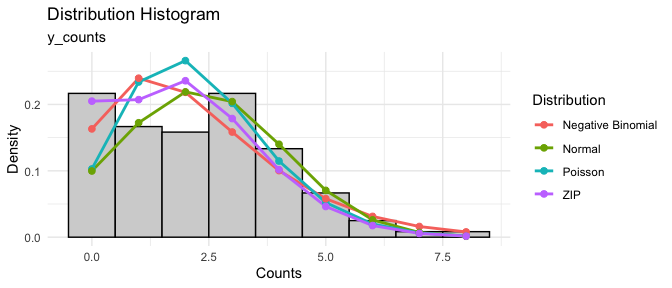

```r
library(PrecisionCalc)

# Simulated discrete data
 y_counts <- c(rpois(100, 3), rep(0,20))

# Plot histogram with fitted distributions
plot_distributionsD(y_counts)
```

## 2. Visualizing Continuous Distributions

`plot_distributionsC()` plots a histogram of continuous data and overlays:

- Normal
- Student-t
- Gamma (MLE)
- Lognormal (MLE)

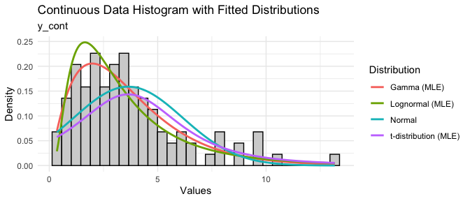

```r
y_cont <- rgamma(100, shape = 2, rate = 0.5)
# Plot histogram with fitted distributions
plot_distributionsC(y_cont)
```

## 3. Sample Size for Relative Precision

`relative_sample()` computes the sample size required to achieve a relative error (epsilon_rel) for discrete or continuous distributions.

```r
# Discrete data
relative_sample(y_counts, epsilon_rel = 0.1, Discrete = TRUE)
```

[output not shown]

```r
# Continuous data
relative_sample(y_cont, epsilon_rel = 0.1, Discrete = FALSE)
```

```
## === Relative Error Sample Size Results ===
## Relative Error: 0.1
## Confidence Level: 0.95
## Distribution Type: Continuous
## Population Size: Infinite
## ----------------------------------------
## Normal Distribution: 183
## t Distribution: 188
## Gamma Distribution: 175
## Lognormal Distribution: 283
## ========================================
```

```r
# Continuos data: ample size of a finite population (N_pop=300)
relative_sample(y_cont, epsilon_rel = 0.1, Discrete = FALSE, N=300)
```

```
## === Relative Error Sample Size Results ===
## Relative Error: 0.1
## Confidence Level: 0.95
## Distribution Type: Continuous
## Population Size: 300
## ----------------------------------------
## Normal Distribution:
##   Infinite Population (n0): 183
##   Finite Population (n_adj): 114
## t Distribution:
##   Infinite Population (n0): 188
##   Finite Population (n_adj): 116
## Gamma Distribution:
##   Infinite Population (n0): 175
##   Finite Population (n_adj): 111
## Lognormal Distribution:
##   Infinite Population (n0): 283
##   Finite Population (n_adj): 146
## ========================================
```

## 4. Relative Sample Size with Zero-Inflated Poisson

`relative_sample_zip()` computes sample size considering a ZIP distribution.

```r
# Add some extra zeros
y_counts_zip <- y_counts
ycounts_zip<-c(y_counts, rep(0,20))

relative_sample_zip(y_counts_zip, epsilon_rel = 0.1)
```

```
## === Relative Error Sample Size Results (ZIP) ===
## Relative Error: 0.1
## Confidence Level: 0.95
## Population Size: Infinite
## ----------------------------------------
## Negative_Binomial Distribution: 262
## Poisson Distribution: 169
## Normal Distribution: 241
## ZIP Distribution: 249
## ========================================
```

## 5. Sample Size for Absolute Precision

`absolute_sample()` computes sample size for a given absolute error.

```r
absolute_sample(y_counts, epsilon = 2, Discrete = TRUE)
```

```
## === Absolute Error Sample Size Results ===
## Absolute Error: 2
## Confidence Level: 0.95
## Distribution Type: Discrete
## Population Size: Infinite
## ----------------------------------------
## Normal Distribution: 4
## Poisson Distribution: 1
## NegBinom Distribution: 4
## ========================================
```

```r
absolute_sample(y_cont, epsilon = 2, Discrete = FALSE)
```

```
## === Absolute Error Sample Size Results ===
## Absolute Error: 2
## Confidence Level: 0.95
## Distribution Type: Continuous
## Population Size: Infinite
## ----------------------------------------
## Normal Distribution: 7
## Student_t Distribution: 7
## Gamma Distribution: 6
## Lognormal Distribution: 10
## ========================================
```

```r
#Sample size of a finite population (N_pop=300)
absolute_sample(y_cont, epsilon = 2, Discrete = FALSE, N=300)
```

[output not shown]

## 6. Bootstrap-based Relative Precision

`bootstrap_precision()` uses bootstrap to estimate the sampling distribution, compute confidence intervals, and track relative precision across increasing sample sizes. It calculates the precision for both an infinite population size or from a complete sample (finite population size).

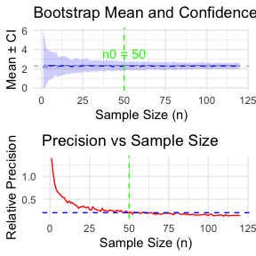

```
## === Bootstrap Precision Sample Size Results ===
## Required Sample Size (n0): 50
## Population Size: Infinite
## Precision Target: 0.2
## Achieved Precision: 0.194
## Confidence Level: 0.95
## Bootstrap Replicates: 200
## Estimated Mean: 2.2706
## Confidence Interval: [1.7795, 2.6605]
## Confidence Interval Width: 0.881
## Pilot Sample Size: 120
## ===============================================
```

```r
set.seed(123)
# Sample size achieving desired relative precision with CI
bootstrap_precision(y_counts, epsilon_rel = 0.2, n_boot = 200)
```

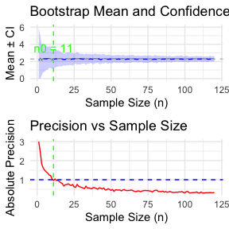

```
## === Bootstrap Precision Sample Size Results ===
## Required Sample Size (n0): 11
## Population Size: Infinite
## Precision Target: 1
## Achieved Precision: 0.9557
## Confidence Level: 0.95
## Bootstrap Replicates: 200
## Estimated Mean: 2.2809
## Confidence Interval: [1.2705, 3.1818]
## Confidence Interval Width: 1.9114
## Pilot Sample Size: 120
## ===============================================
```

```r
# Sample size achieving desired absolute precision with CI
bootstrap_precision(y_counts, epsilon = 1, n_boot = 200)
```

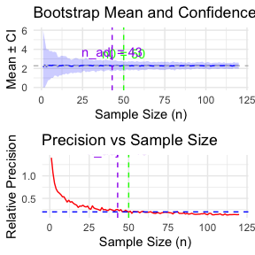

```
## === Bootstrap Precision Sample Size Results ===
## Required Sample Size (n0): 50
## Adjusted Sample Size (n_adj): 43
## Population Size (N): 300
## Precision Target: 0.2
## Achieved Precision: 0.194
## Confidence Level: 0.95
## Bootstrap Replicates: 200
## Estimated Mean: 2.2706
## Confidence Interval: [1.7795, 2.6605]
## Confidence Interval Width: 0.881
## Pilot Sample Size: 120
## ===============================================
```

```r
#Sample size of a finite population (N_pop=300)
bootstrap_precision(y_counts, epsilon_rel = 0.2, n_boot = 200, N_pop=300)
```

## 7. Sample Size for Binomial Proportion

```r
y_bin<-c(0,0,0,1,0,1,0,0,0,1,0,0,1,1)
sample_size_binomial (y_bin, p = NULL, epsilon=0.02, conf = 0.95, N = NULL)
```

```
## === Binomial Proportion Sample Size Results ===
## Sample Size: 2205
## Proportion: 0.3571
## Precision Type: Absolute
## Precision Used: 0.02
## Absolute Error: 0.02
## Confidence Level: 0.95
## Population Size: Inf
## Confidence Interval: [0.3371, 0.3771]
```

## 8. Sample Size for Beta Distribution

`sample_size_beta()` computes the required sample size to estimate the mean of a Beta distribution for a given absolute error and confidence level.  
If the input data contain 0 or 1 values, the function automatically applies the Smithson & Verkuilen (2006) transformation to avoid issues with the Beta distribution.

```r
# Example with observed data including 0s
y_beta <- c(0.2, 0.1, 0, 0, 0, 0.4)
sample_size_beta(x = y_beta, epsilon = 0.05, conf = 0.95)
```

```
## === Beta Distribution Sample Size Results ===
## Sample Size: 28
## Mean: 0.1806
## Precision Type: Absolute
## Precision Used: 0.05
## Absolute Error: 0.05
## Confidence Level: 0.95
## Population Size: Inf
## Confidence Interval: [0.1306, 0.2306]
```

```r
# Example with known Beta parameters
sample_size_beta(alpha = 2, beta = 5, epsilon = 0.05, conf = 0.95, N = 500)
```

```
## === Beta Distribution Sample Size Results ===
## Sample Size: 37
## Mean: 0.2857
## Precision Type: Absolute
## Precision Used: 0.05
## Absolute Error: 0.05
## Confidence Level: 0.95
## Population Size: 500
## Confidence Interval: [0.2357, 0.3357]
```

## 9. Finite Population Correction

`finite_population_correction()` adjusts an initial sample size n0 (calculated assuming an infinite population) to account for a finite population size N.

```r
n0 <- 50   # sample size from relative/absolute precision
N  <- 200  # total population size

finite_population_correction(n0, N)
```

```
## [1] 41
```

## 10. Summary of Functions

Summary of PrecisionCalc Functions

[output not shown]

### References

```
    • Elliot, J.M. (1977) Some Methods for the Statistical Analysis of Samples of Benthic Invertebrates. 2nd Edition, Freshwater Biological Publ. 25, Freshwater Biological Association, Ambleside, 160 p.
    •   Thompsom, S.K. (2012). Sampling (Wiley series in probability and statistics, 755) 3rd edition.
    • Venables, W.N. & Ripley, B.D. (2002). Modern Applied Statistics with S. 4th edition.
  • R packages: MASS, fitdistrplus, pscl, ggplot2.
```

## Notes for Users

These are important guidelines for effectively using the **`PrecisionCalc`** package functions:

1. **Error scale consistency**
   - Always ensure your `epsilon` (absolute or relative error) is in the same scale as your data.
   - For counts or measurements: use the same units as your data.
   - For proportions (0–1 or percentages): ensure consistency between `p` and `epsilon`.
2. **Finite population adjustment**
   - For small populations (finite populations), provide population size parameter `N` in the functions: `relative_sample()`, `relative_sample_zip()` `absolute_sample()`, `sample_size_binomial()` and `sample_size_beta()`. If `N` is not provided an infinite population will be assumed.
   - This avoids oversampling when the population size `N` is limited. `finite_population_correction()` function can perform the same adjustment after analysis if `N` was not provided initially.
3. **Bootstrap-based precision**
   - Use `bootstrap_precision()` when parametric assumptions (Normal, Poisson, etc.) are uncertain.
   - This function estimates precision non-parametrically using resampling, and helps visualize how precision improves with increasing sample size. It works both for relative or absolute precision and both infinite or finite populations. If working with finite populations the population size (N_pop) should be provided.
4. **Binomial data sampling**
   - `sample_size_binomial()` allows automatic estimation of the proportion `p` from observed 0/1 data.
   - You can also provide a known expected proportion `p`.
   - If the entire population is known, supply `N` to apply finite population correction automatically.
5. **A typical workflow recommendation**
   1. Compute an initial sample size using `relative_sample()`, `absolute_sample()`, or `sample_size_binomial()`.
   2. Adjust for finite population using `finite_population_correction()`.
   3. Optionally, check precision with `bootstrap_precision()`.
6. **Visualization**
   - Always visualize your data with `plot_distributionsD()` or `plot_distributionsC()` before performing sample size calculations.
   - This helps ensure that distributional assumptions match your data.